# Les relations des pays du monde aux énergies

Ce Markdown a pour but de présenter les différentes illustrations et modèles développés. Les analyses et interprétations sont disponibles dans la notice.

## PARTIE 1: ACQUISITION DES DONNEES:

Dans cette partie, on s’occupe de réucpérer les données sous format brut et d’appliquer une série de transformations (nettoyage,suppression de colonnes, ajout de colonnes)

Premières lignes du dataset formaté

| Entity | Year | Access.to.electricity….of.population. | Access.to.clean.fuels.for.cooking | Financial.flows.to.developing.countries..US… | Renewable.energy.share.in.the.total.final.energy.consumption…. | Electricity.from.fossil.fuels..TWh. | Electricity.from.nuclear..TWh. | Electricity.from.renewables..TWh. | Low.carbon.electricity….electricity. | Primary.energy.consumption.per.capita..kWh.person. | Energy.intensity.level.of.primary.energy..MJ..2017.PPP.GDP. | Value_co2_emissions_kt_by_country | gdp_growth | gdp_per_capita | Continent |
| --- | --- | --- | --- | --- | --- | --- | --- | --- | --- | --- | --- | --- | --- | --- | --- |
| Afghanistan | 2000 | 1.613591 | 6.2 | 20000 | 44.99 | 0.16 | 0 | 0.31 | 65.95744 | 302.5948 | 1.64 | 760 | 6.163893 | 439.0558 | Asia |
| Afghanistan | 2001 | 4.074574 | 7.2 | 130000 | 45.60 | 0.09 | 0 | 0.50 | 84.74577 | 236.8919 | 1.74 | 730 | 6.163893 | 439.0558 | Asia |
| Afghanistan | 2002 | 9.409158 | 8.2 | 3950000 | 37.83 | 0.13 | 0 | 0.56 | 81.15942 | 210.8622 | 1.40 | 1030 | 6.163893 | 179.4266 | Asia |
| Afghanistan | 2003 | 14.738506 | 9.5 | 25970000 | 36.66 | 0.31 | 0 | 0.63 | 67.02128 | 229.9682 | 1.40 | 1220 | 8.832278 | 190.6838 | Asia |
| Afghanistan | 2004 | 20.064968 | 10.9 | 32969474 | 44.24 | 0.33 | 0 | 0.56 | 62.92135 | 204.2312 | 1.20 | 1030 | 1.414118 | 211.3821 | Asia |
| Afghanistan | 2005 | 25.390894 | 12.2 | 9830000 | 33.88 | 0.34 | 0 | 0.59 | 63.44086 | 252.0691 | 1.41 | 1550 | 11.229715 | 242.0313 | Asia |

## PARTIE 2: L’ACCES AUX ENERGIES DANS DIFFERENTS PAYS

Dans cette partie, nous nous focaliserons sur l’étude de l’accès aux énergies renouvelables dans différents pays

### 2.1 : Relation PIB/Accès à l’électricité

L’objectif ici va être de tracer un nuage de points pour vérifier notre intuitition de cette relation, puis d’effectuer un test d’ANOVA sur un modèle pour valider cette intuition

Nous avons le tracé du nuage de points suivant:

[interactive chart not shown]

Les modèles intervenant dans le test d’ANOVA sont les modèles Modèle 1 ANOVA : Access.to.electricity….of.population. ~ Entity + Year + gdp_per_capita et Modèle 2 ANOVA : Access.to.electricity….of.population. ~ Entity + Year + gdp_per_capita + gdp_growth.

Modèle 1 ANOVA : Access.to.electricity….of.population. ~ Entity + Year + gdp_per_capita | R² ajusté : 0.9616

| Source | ddl | Sommes carrés | Moyennes carrés | F-value | P-value |
| --- | --- | --- | --- | --- | --- |
| Entity | 147 | 2894505.40 | 19690.51 | 487.41 | 0 |
| Year | 1 | 64372.58 | 64372.58 | 1593.45 | 0 |
| gdp_per_capita | 1 | 9655.10 | 9655.10 | 239.00 | 0 |
| Residuals | 2931 | 118407.01 | 40.40 | NA | NA |

Modèle 2 ANOVA : Access.to.electricity….of.population. ~ Entity + Year + gdp_per_capita + gdp_growth | R² ajusté : 0.9618

| Source | ddl | Sommes carrés | Moyennes carrés | F-value | P-value |
| --- | --- | --- | --- | --- | --- |
| Entity | 147 | 2894505.40 | 19690.51 | 489.54 | 0.0000000 |
| Year | 1 | 64372.58 | 64372.58 | 1600.40 | 0.0000000 |
| gdp_per_capita | 1 | 9655.10 | 9655.10 | 240.04 | 0.0000000 |
| gdp_growth | 1 | 554.22 | 554.22 | 13.78 | 0.0002095 |
| Residuals | 2930 | 117852.78 | 40.22 | NA | NA |

### 2.2 : Disparités dans l’accès aux énergies propres pour la cuisine entre continents

L’objectif ici va être d’utiliser un violin plot pour visualiser les écarts inter et intra continents dans la moyenne sur les années 2000 à 2019 dans l’accès aux énergies propres pour la cuisine

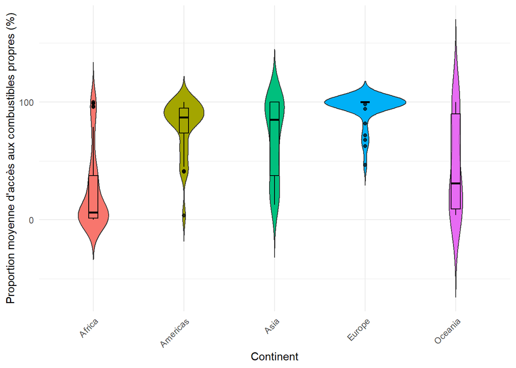

### 2.3 : Analyse de l’évolution de la consommation moyenne par zone

Nous pouvons également partitionner les pays en trois groupes selon qu’ils consomment beaucoup, moyennement ou peu d’énergie (par kmeans) puis voir comment évolue la part des énergies renouvelables dans la consommation totale d’énergie en fonction du temps pour repérer des pays à surveiller (énergivores et très dépendants des énergies non renouvelables, donc périssables) à l’aide d’un graphe par groupe

On souhaite tracer uniquement 7 pays maximum par groupe pour des raisons de lisibilité

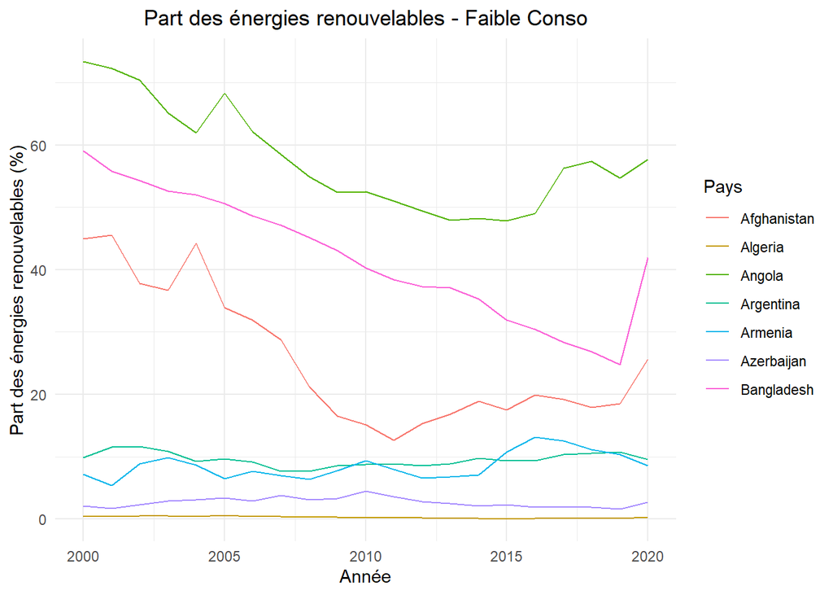

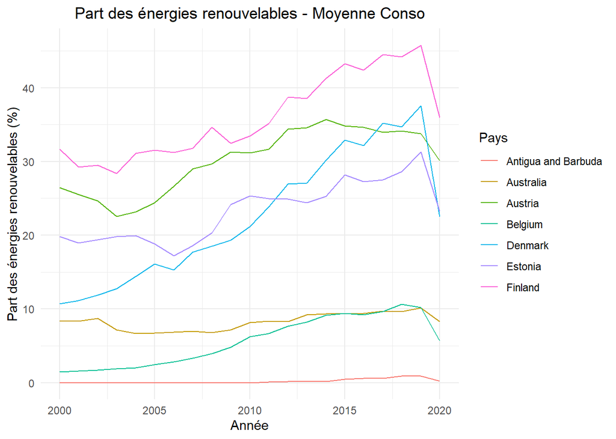

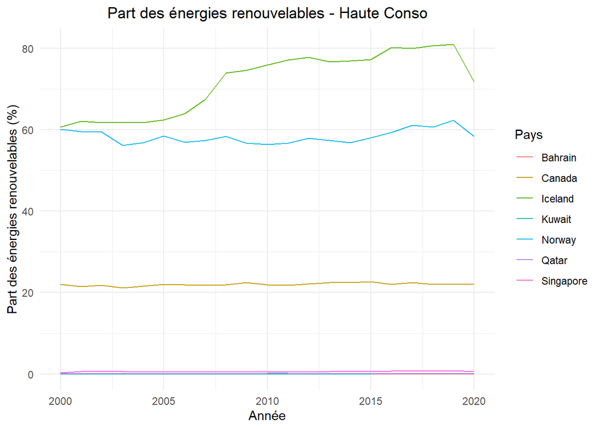

## PARTIE 3: L’IMPACT ENERGETIQUE DES DIFFERENTS PAYS DANS LE MONDE:

### 3.1: Intensité énergétique par pays

Ici, nous réalisons la carte choroplèthe de l’intensité énergétique en fonction des pays en 2019:

```
## 146 codes from your data successfully matched countries in the map
## 2 codes from your data failed to match with a country code in the map
## 97 codes from the map weren't represented in your data
```

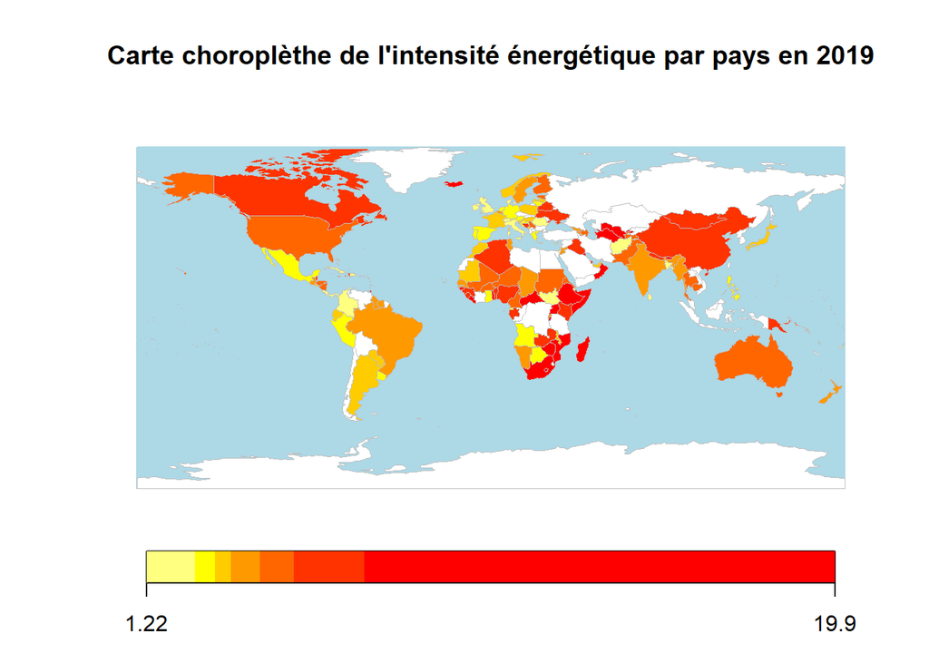

Nous pouvons également nous appuyer sur une Heatmap pour analyser l’évolution au fil des années de l’intensité énergétique par pays:

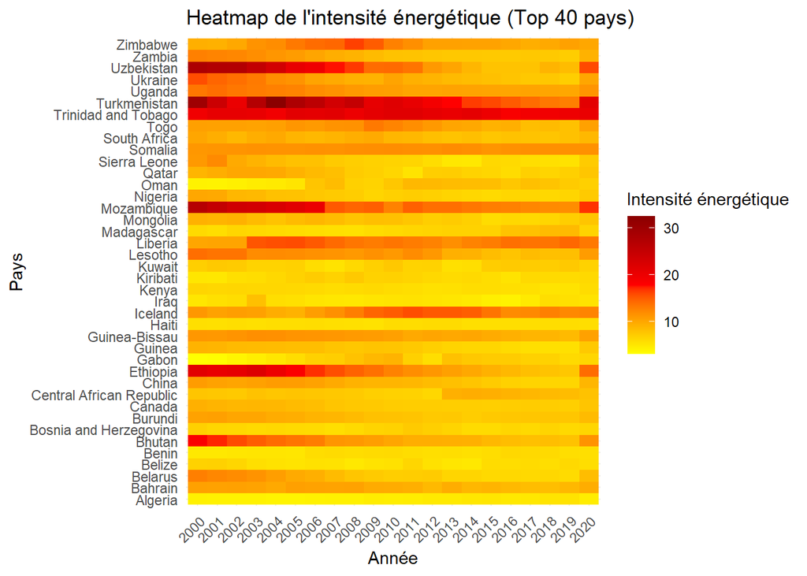

### 3.2 Comment expliquer les émissions de CO2 des différents pays ?

Nous allons réaliser ici un modèle linéaire afin d’essayer d’expliquer les émissions de CO2 par plusieurs variables:

Critères AIC pour les modèles

| Model | AIC |
| --- | --- |
| Modèle 1 | -2627.043 |
| Modèle 2 | -2637.369 |
| Modèle 3 | -2941.896 |
| Modèle 4 | -3031.161 |
| Modèle 5 | -3181.264 |
| Modèle 6 | -3186.275 |
| Modèle 7 | -13381.038 |

Résumé du meilleur modèle (R² : 0.982, R² ajusté : 0.982)

| Variable | Coefficient | Std. Error | t-value | p-value |
| --- | --- | --- | --- | --- |
| (Intercept) | -0.0168830 | 0.0005488 | -30.765836 | 0.0000000 |
| Energy_Intensity | 0.0014788 | 0.0006368 | 2.322404 | 0.0202858 |
| Primary_Energy | 0.0040244 | 0.0014863 | 2.707616 | 0.0068199 |
| Renewable_Share | -0.0027236 | 0.0006055 | -4.498361 | 0.0000071 |
| GDP_per_Capita | -0.0013824 | 0.0010188 | -1.356943 | 0.1749135 |
| Low_Carbon_Electricity | 0.0058932 | 0.0004497 | 13.103702 | 0.0000000 |
| Fossil_Fuel_Electricity | 0.8966361 | 0.0026255 | 341.509577 | 0.0000000 |

On affiche les diagnostic plots

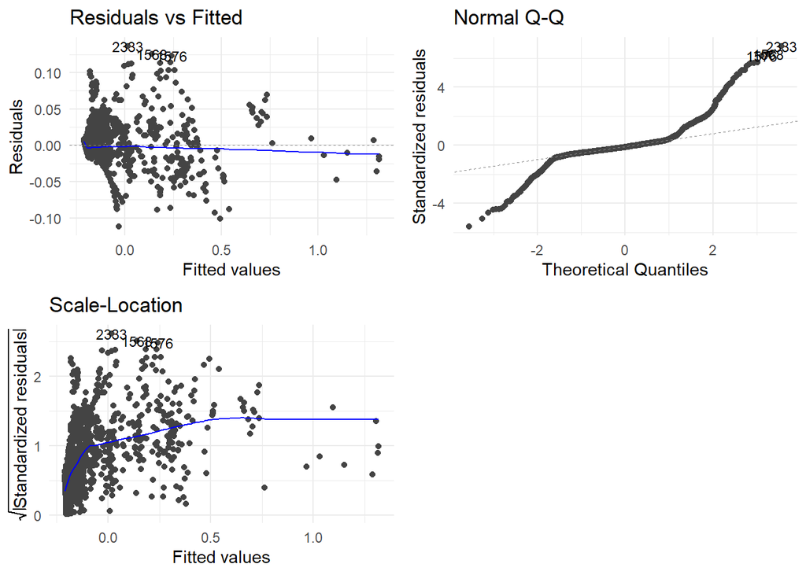

Le test de Breusch-Pagan vient confirmer la non homoscédasticité des résidus

```
##
##  studentized Breusch-Pagan test
##
## data:  best_model
## BP = 366.19, df = 6, p-value < 2.2e-16
```

## PARTIE 4 : Effort des pays envers la validation des objectifs d’energies renouvelables

### 4.1 : Les énergies renouvelables par pays

Création de la carte choroplèthe de la part des énergies renouvelable dans la consommation finale d’énergie par pays:

```
## 146 codes from your data successfully matched countries in the map
## 2 codes from your data failed to match with a country code in the map
##      failedCodes failedCountries
## [1,] NA          "Eswatini"
## [2,] NA          "North Macedonia"
## 97 codes from the map weren't represented in your data
```

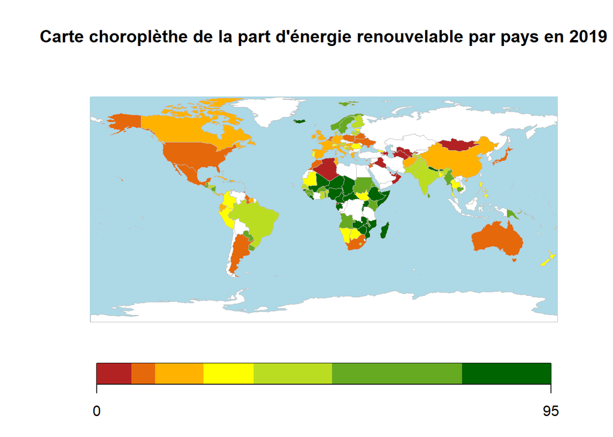

Nous pouvons également nous baser sur un diagramme de bârres groupées pour visualiser les différences entre les continents:

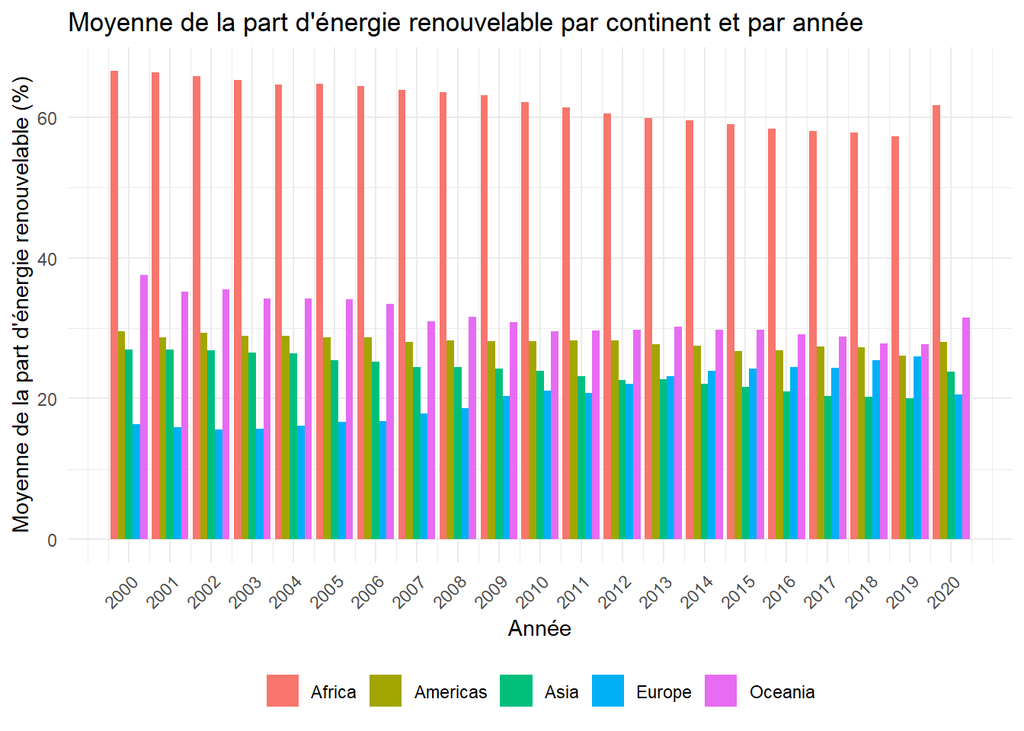

### 4.2 : Etude d’une possible relation entre les financements et les scores élevés des pays en voie de développement dans la part des énergies renouvelables dans la consommation finale:

```
##
## Call:
## lm(formula = Renewable_Share ~ Financial_Flows + log(GDP_Growth) +
##     Year, data = financial_data)
##
## Residuals:
##     Min      1Q  Median      3Q     Max
## -0.9714 -0.4758 -0.1904  0.2840  2.2813
##
## Coefficients:
##                   Estimate Std. Error t value Pr(>|t|)
## (Intercept)     -16.284207   8.898777  -1.830   0.0677 .
## Financial_Flows   0.011409   0.032526   0.351   0.7259
## log(GDP_Growth)  -0.109408   0.019039  -5.747 1.32e-08 ***
## Year              0.007678   0.004422   1.736   0.0829 .
## ---
## Signif. codes:  0 '***' 0.001 '**' 0.01 '*' 0.05 '.' 0.1 ' ' 1
##
## Residual standard error: 0.647 on 755 degrees of freedom
##   (1326 observations effacées parce que manquantes)
## Multiple R-squared:  0.04277,    Adjusted R-squared:  0.03896
## F-statistic: 11.24 on 3 and 755 DF,  p-value: 3.189e-07
```

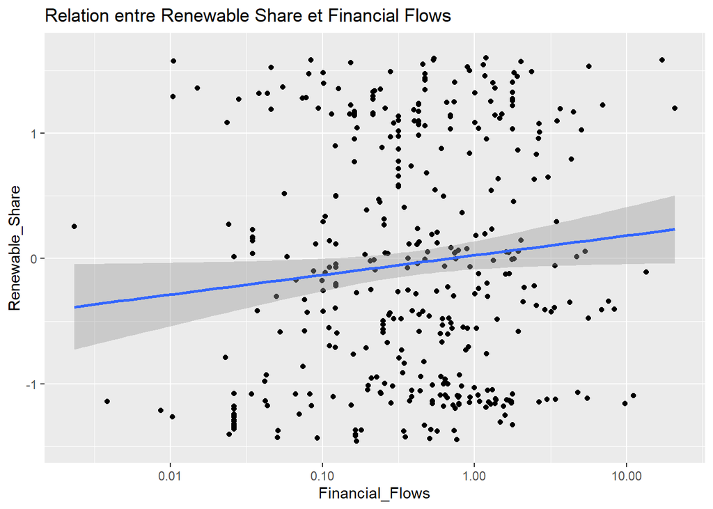

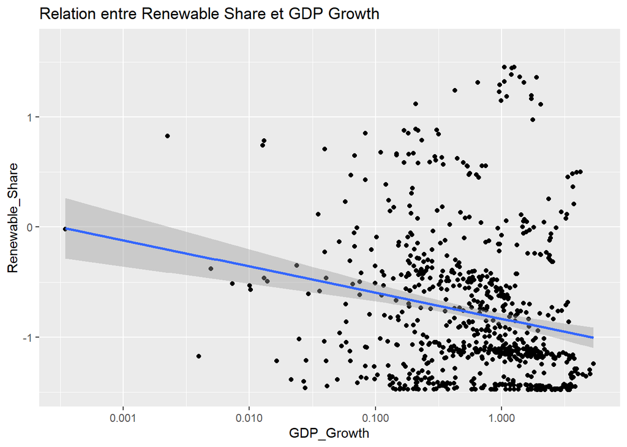